# Turn up the Heat! A Tutorial for the MAGMA R-package.

### Balance Estimation and Visualization

The only difference to the previous examples in the process is, that the grouping variable is a character vector of length two. As a result of this, `Plot_MAGMA` displays three Pillai’s Trace plots corresponding to the two main effects and the interaction.

```r
Balance_2x2 <- Balance_MAGMA(Data = MAGMA_sim_data_2x2,
                             group = c("gifted_support", "enrichment"),
                             covariates = covariates_2x2,
                             step = "step")
```

```
#>
#>  Start estimating Pillai's Trace.
#>  Pillai's Trace finished. Starting to compute d-ratio.
#>  d-ratio finished. Starting to compute mean-g.
#>
#>  Mean g was computed using robust variance meta-analysis with robumeta.
#>  Mean g finished. Starting to compute adjusted d-ratio.
#>  Adjusted d-ratio finished. balance estimation
```

```r
# Balance criteria for 100 cases per group
Balance_100_2x2_criteria <- Balance_extract(Balance = Balance_2x2,
                                            samplesize = 100,
                                            effects = FALSE)
Balance_100_2x2_criteria
```

```
#> Pillai's Trace ME 1 Pillai's Trace ME 2   Pillai's Trace IA             d-ratio
#>                0.02                0.01                0.02                0.73
#>              mean g        adj. d-ratio
#>                0.16                0.60
```

```r
# Extracting pairwise effects for 100 cases per group
Balance_100_2x2_effects <- Balance_extract(Balance = Balance_2x2,
                                           samplesize = 100,
                                           effects = TRUE)
Balance_100_2x2_effects
```

```
#>       GPA_school_1_2         IQ_score_1_2       Motivation_1_2
#>                 0.17                 0.12                 0.17
#> parents_academic_1_2           gender_1_2       GPA_school_1_3
#>                 0.22                 0.06                 0.10
#>         IQ_score_1_3       Motivation_1_3 parents_academic_1_3
#>                 0.03                 0.21                 0.10
#>           gender_1_3       GPA_school_1_4         IQ_score_1_4
#>                 0.12                 0.01                 0.27
#>       Motivation_1_4 parents_academic_1_4           gender_1_4
#>                 0.34                 0.19                 0.06
#>       GPA_school_2_3         IQ_score_2_3       Motivation_2_3
#>                 0.07                 0.09                 0.03
#> parents_academic_2_3           gender_2_3       GPA_school_2_4
#>                 0.12                 0.18                 0.19
#>         IQ_score_2_4       Motivation_2_4 parents_academic_2_4
#>                 0.38                 0.17                 0.41
#>           gender_2_4       GPA_school_3_4         IQ_score_3_4
#>                 0.12                 0.12                 0.29
#>       Motivation_3_4 parents_academic_3_4           gender_3_4
#>                 0.14                 0.29                 0.06
```

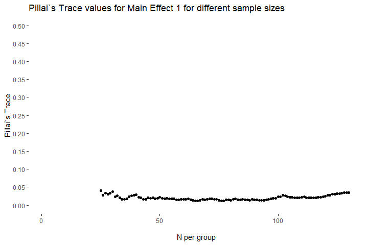

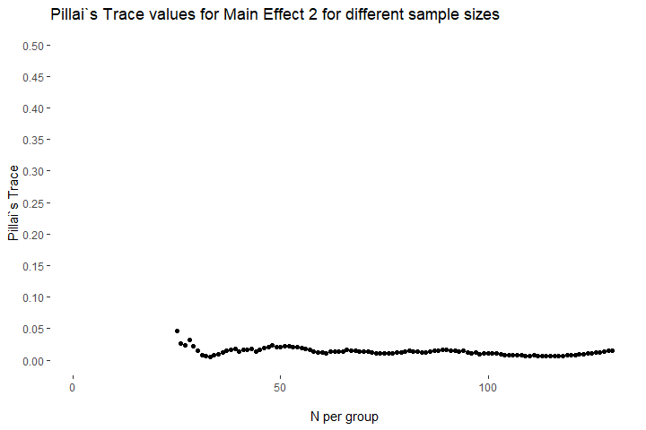

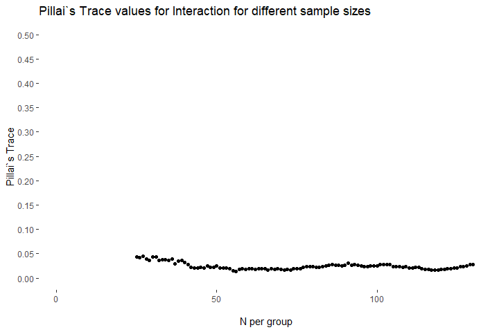

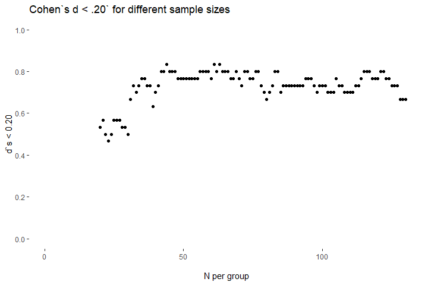

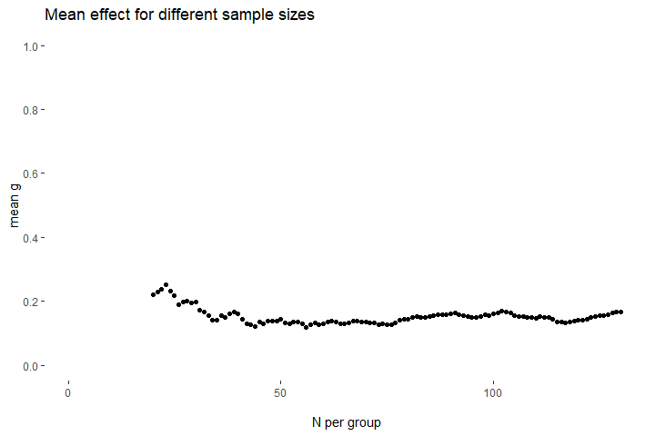

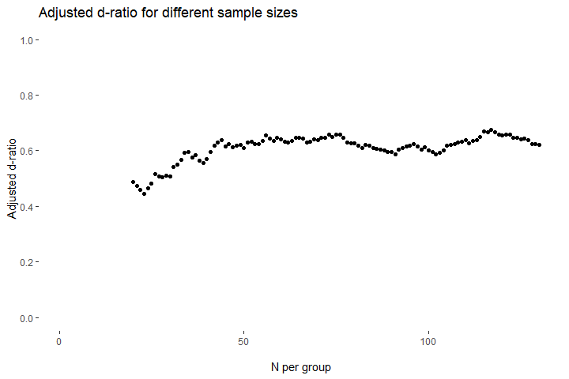

```r
# Plotting trend over increasing sample size
Plot_MAGMA(Balance = Balance_2x2,
           criterion = c("Pillai", "d_ratio", "mean_g", "Adj_d_ratio"))
```

```r
# Creating table
Table_MAGMA(Balance = Balance_2x2,
            filename = "Balance_2x2.docx")
```

```
#> Balance table successfully created!
#> # A tibble: 6 × 8
#>   Criterion_optimized Pillai_Trace_ME1 Pillai_Trace_ME2 Pillai_Trace_IA d_ratio
#>   <chr>                          <dbl>            <dbl>           <dbl>   <dbl>
#> 1 Best Pillai ME 2                0.02             0               0.04   0.7
#> 2 Best Pillai IA                  0.02             0.02            0.01   0.8
#> 3 Best mean g                     0.02             0.02            0.01   0.8
#> 4 Best d-ratio                    0.02             0.01            0.02   0.833
#> 5 Best Pillai ME 1                0.01             0.01            0.02   0.8
#> 6 Best adj. d-ratio               0.02             0.01            0.02   0.8
#> # ℹ 3 more variables: mean_g <dbl>, adjusted_d_ratio <dbl>, n_per_group <int>
```

```r
# Computing descriptive statistics and all pairwise effects after matching
descs_2x2_post <- MAGMA_desc(Data = MAGMA_sim_data_2x2,
                             group = c("gifted_support", "enrichment"),
                             covariates = covariates_2x2,
                             step_num = 100,
                             step_var = "step",
                             filename = "stats_post_pre.docx")
```

```
#> 2x2 groups are represented as 4 groups.
```

```r
descs_2x2_post %>%
  purrr::set_names(c("Overall N", "Overall Mean", "Overall SD",
                     "Sup & No En N", "Sup & No En Mean",
                     "Sup & No En SD",
                     "Sup & En N", "Sup & En Mean", "Sup & En SD",
                     "No Sup & No En N", "No Sup & No En Mean", "No Sup & No En SD",
                     "No Sup & En N", "No Sup & En Mean", "No Sup & En SD",
                     "d YesNo-YesYes", "d YesNo-NoNo", "d YesNo-NoYes",
                     "d YesYes-NoNo", "d YesYes-YNoYes",
                     "d NoNo-NoYes"))
```

```
#>                  Overall N Overall Mean Overall SD Sup & No En N
#> group_long             400         2.50       1.12           100
#> GPA_school             400         3.52       0.86           100
#> IQ_score               400       104.15      11.20           100
#> Motivation             400         3.90       0.85           100
#> parents_academic       400         0.44       0.50           100
#> gender                 400         0.52       0.50           100
#>                  Sup & No En Mean Sup & No En SD Sup & En N Sup & En Mean
#> group_long                   1.00           0.00        100          2.00
#> GPA_school                   3.46           0.90        100          3.61
#> IQ_score                   104.55          10.59        100        105.81
#> Motivation                   3.74           0.88        100          3.89
#> parents_academic             0.42           0.50        100          0.53
#> gender                       0.50           0.50        100          0.47
#>                  Sup & En SD No Sup & No En N No Sup & No En Mean
#> group_long              0.00              100                3.00
#> GPA_school              0.86              100                3.55
#> IQ_score               10.29              100              104.85
#> Motivation              0.85              100                3.92
#> parents_academic        0.50              100                0.47
#> gender                  0.50              100                0.56
#>                  No Sup & No En SD No Sup & En N No Sup & En Mean
#> group_long                    0.00           100             4.00
#> GPA_school                    0.89           100             3.46
#> IQ_score                     10.79           100           101.40
#> Motivation                    0.83           100             4.03
#> parents_academic              0.50           100             0.33
#> gender                        0.50           100             0.53
#>                  No Sup & En SD d YesNo-YesYes d YesNo-NoNo d YesNo-NoYes
#> group_long                 0.00           -Inf         -Inf          -Inf
#> GPA_school                 0.78          -0.17        -0.10          0.00
#> IQ_score                  12.66          -0.12        -0.03          0.27
#> Motivation                 0.85          -0.17        -0.21         -0.34
#> parents_academic           0.47          -0.22        -0.10          0.19
#> gender                     0.50           0.06        -0.12         -0.06
#>                  d YesYes-NoNo d YesYes-YNoYes d NoNo-NoYes
#> group_long                -Inf            -Inf         -Inf
#> GPA_school                0.07            0.18         0.11
#> IQ_score                  0.09            0.38         0.29
#> Motivation               -0.04           -0.17        -0.13
#> parents_academic          0.12            0.41         0.29
#> gender                   -0.18           -0.12         0.06
```

```r
Balance_2x2 <- Balance_MAGMA(Data = MAGMA_sim_data_2x2,
                             group = c("gifted_support", "enrichment"),
                             covariates = covariates_2x2,
                             step = "step")
```

```r
# Balance criteria for 100 cases per group
Balance_100_2x2_criteria <- Balance_extract(Balance = Balance_2x2,
                                            samplesize = 100,
                                            effects = FALSE)
Balance_100_2x2_criteria
```

```
#> Pillai's Trace ME 1 Pillai's Trace ME 2   Pillai's Trace IA             d-ratio
#>                0.02                0.01                0.02                0.73
#>              mean g        adj. d-ratio
#>                0.16                0.60
```

```r
# Extracting pairwise effects for 100 cases per group
Balance_100_2x2_effects <- Balance_extract(Balance = Balance_2x2,
                                           samplesize = 100,
                                           effects = TRUE)
Balance_100_2x2_effects
```

```
#>       GPA_school_1_2         IQ_score_1_2       Motivation_1_2
#>                 0.17                 0.12                 0.17
#> parents_academic_1_2           gender_1_2       GPA_school_1_3
#>                 0.22                 0.06                 0.10
#>         IQ_score_1_3       Motivation_1_3 parents_academic_1_3
#>                 0.03                 0.21                 0.10
#>           gender_1_3       GPA_school_1_4         IQ_score_1_4
#>                 0.12                 0.01                 0.27
#>       Motivation_1_4 parents_academic_1_4           gender_1_4
#>                 0.34                 0.19                 0.06
#>       GPA_school_2_3         IQ_score_2_3       Motivation_2_3
#>                 0.07                 0.09                 0.03
#> parents_academic_2_3           gender_2_3       GPA_school_2_4
#>                 0.12                 0.18                 0.19
#>         IQ_score_2_4       Motivation_2_4 parents_academic_2_4
#>                 0.38                 0.17                 0.41
#>           gender_2_4       GPA_school_3_4         IQ_score_3_4
#>                 0.12                 0.12                 0.29
#>       Motivation_3_4 parents_academic_3_4           gender_3_4
#>                 0.14                 0.29                 0.06
```

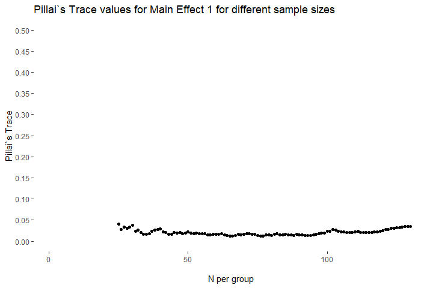

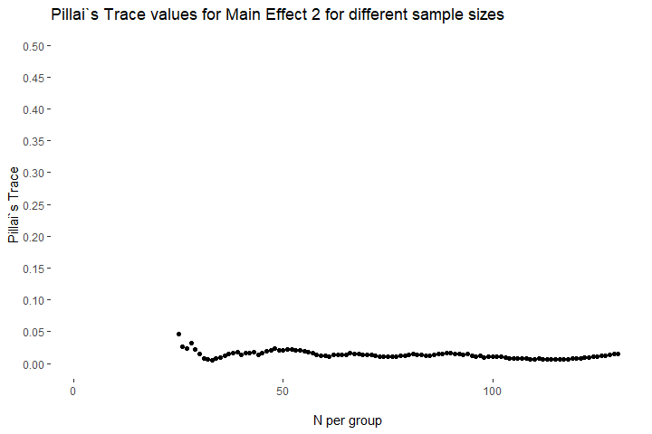

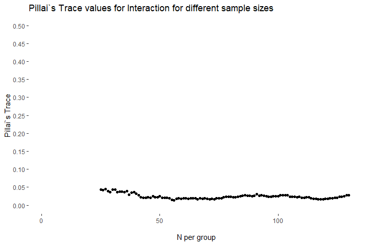

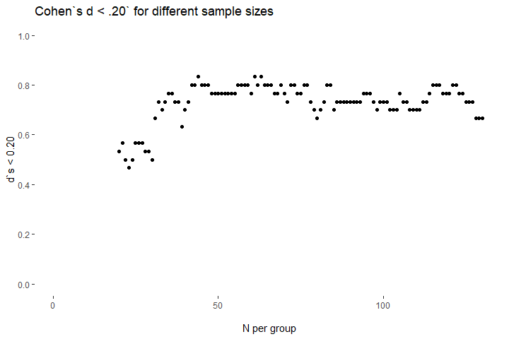

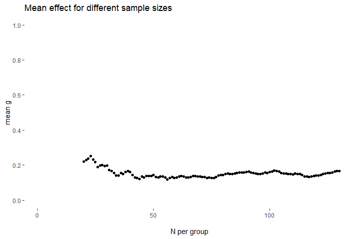

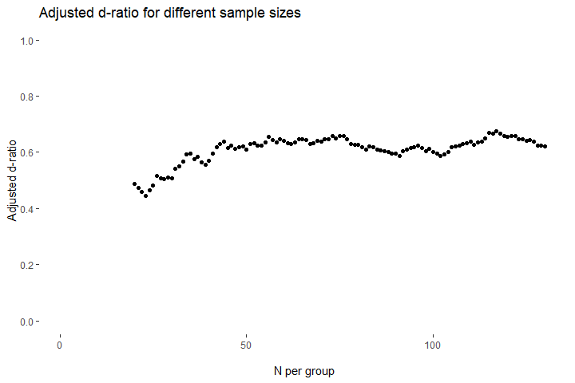

```r
# Plotting trend over increasing sample size
Plot_MAGMA(Balance = Balance_2x2,
           criterion = c("Pillai", "d_ratio", "mean_g", "Adj_d_ratio"))
```

```r
# Creating table
Table_MAGMA(Balance = Balance_2x2,
            filename = "Balance_2x2.docx")
```

```
#> Balance table successfully created!
#> # A tibble: 6 × 8
#>   Criterion_optimized Pillai_Trace_ME1 Pillai_Trace_ME2 Pillai_Trace_IA d_ratio
#>   <chr>                          <dbl>            <dbl>           <dbl>   <dbl>
#> 1 Best Pillai ME 2                0.02             0               0.04   0.7
#> 2 Best Pillai IA                  0.02             0.02            0.01   0.8
#> 3 Best mean g                     0.02             0.02            0.01   0.8
#> 4 Best d-ratio                    0.02             0.01            0.02   0.833
#> 5 Best Pillai ME 1                0.01             0.01            0.02   0.8
#> 6 Best adj. d-ratio               0.02             0.01            0.02   0.8
#> # ℹ 3 more variables: mean_g <dbl>, adjusted_d_ratio <dbl>, n_per_group <int>
```

```r
# Computing descriptive statistics and all pairwise effects after matching
descs_2x2_post <- MAGMA_desc(Data = MAGMA_sim_data_2x2,
                             group = c("gifted_support", "enrichment"),
                             covariates = covariates_2x2,
                             step_num = 100,
                             step_var = "step",
                             filename = "stats_post_pre.docx")
```

```
#> 2x2 groups are represented as 4 groups.
```

```r
descs_2x2_post %>%
  purrr::set_names(c("Overall N", "Overall Mean", "Overall SD",
                     "Sup & No En N", "Sup & No En Mean",
                     "Sup & No En SD",
                     "Sup & En N", "Sup & En Mean", "Sup & En SD",
                     "No Sup & No En N", "No Sup & No En Mean", "No Sup & No En SD",
                     "No Sup & En N", "No Sup & En Mean", "No Sup & En SD",
                     "d YesNo-YesYes", "d YesNo-NoNo", "d YesNo-NoYes",
                     "d YesYes-NoNo", "d YesYes-YNoYes",
                     "d NoNo-NoYes"))
```

```
#>                  Overall N Overall Mean Overall SD Sup & No En N
#> group_long             400         2.50       1.12           100
#> GPA_school             400         3.52       0.86           100
#> IQ_score               400       104.15      11.20           100
#> Motivation             400         3.90       0.85           100
#> parents_academic       400         0.44       0.50           100
#> gender                 400         0.52       0.50           100
#>                  Sup & No En Mean Sup & No En SD Sup & En N Sup & En Mean
#> group_long                   1.00           0.00        100          2.00
#> GPA_school                   3.46           0.90        100          3.61
#> IQ_score                   104.55          10.59        100        105.81
#> Motivation                   3.74           0.88        100          3.89
#> parents_academic             0.42           0.50        100          0.53
#> gender                       0.50           0.50        100          0.47
#>                  Sup & En SD No Sup & No En N No Sup & No En Mean
#> group_long              0.00              100                3.00
#> GPA_school              0.86              100                3.55
#> IQ_score               10.29              100              104.85
#> Motivation              0.85              100                3.92
#> parents_academic        0.50              100                0.47
#> gender                  0.50              100                0.56
#>                  No Sup & No En SD No Sup & En N No Sup & En Mean
#> group_long                    0.00           100             4.00
#> GPA_school                    0.89           100             3.46
#> IQ_score                     10.79           100           101.40
#> Motivation                    0.83           100             4.03
#> parents_academic              0.50           100             0.33
#> gender                        0.50           100             0.53
#>                  No Sup & En SD d YesNo-YesYes d YesNo-NoNo d YesNo-NoYes
#> group_long                 0.00           -Inf         -Inf          -Inf
#> GPA_school                 0.78          -0.17        -0.10          0.00
#> IQ_score                  12.66          -0.12        -0.03          0.27
#> Motivation                 0.85          -0.17        -0.21         -0.34
#> parents_academic           0.47          -0.22        -0.10          0.19
#> gender                     0.50           0.06        -0.12         -0.06
#>                  d YesYes-NoNo d YesYes-YNoYes d NoNo-NoYes
#> group_long                -Inf            -Inf         -Inf
#> GPA_school                0.07            0.18         0.11
#> IQ_score                  0.09            0.38         0.29
#> Motivation               -0.04           -0.17        -0.13
#> parents_academic          0.12            0.41         0.29
#> gender                   -0.18           -0.12         0.06
```

## Exact Matching

We use the same covariates as we used for the standard 2x2 matching. The only change constitutes the use of `teacher_ability_rating` as an exact variable. This means that only students with same teacher rated ability can be matched (e.g., above average with above average). Below is the entire matching, balance estimation, and visualization process. Initial unbalance, descriptive statistics, and area of common support are the same as for standard matching.

```r
MAGMA_sim_data_2x2_exact <- MAGMA_exact(Data = MAGMA_sim_data,
                                        group = c("gifted_support", "enrichment"),
                                        dist = "ps_2x2",
                                        exact = "teacher_ability_rating",
                                        cores = 2)
```

```
#>
#>  Input correctly identified!
#>  Distance computation finished. Starting matching
#>  Matching complete!
```

```r
str(MAGMA_sim_data_2x2_exact)
```

```
#> 'data.frame':    520 obs. of  18 variables:
#>  $ ID                    : int  1 2 3 4 5 6 10 13 14 16 ...
#>  $ gender                : int  1 0 1 1 1 0 0 1 0 1 ...
#>  $ gifted_support        : int  1 1 1 1 1 1 1 0 0 0 ...
#>  $ teacher_ability_rating: int  3 2 2 1 3 3 1 3 2 1 ...
#>  $ enrichment            : int  0 1 0 1 0 0 1 0 0 1 ...
#>  $ parents_academic      : int  1 1 1 0 1 0 0 0 0 0 ...
#>  $ GPA_school            : num  4.73 4.41 3.23 2.88 2.98 ...
#>  $ IQ_score              : num  111.6 97.8 120.1 97.9 74.4 ...
#>  $ Motivation            : num  5.36 4.41 3.57 4.34 3.54 ...
#>  $ college_GPA           : num  4.01 3.41 2.73 4.02 4.09 ...
#>  $ support_enrichment    : int  3 4 3 4 3 3 4 1 1 2 ...
#>  $ ps_tar                : num  0.0657 0.1085 0.1899 0.4261 0.4782 ...
#>  $ ps_2x2                : num  0.3 0.32 0.21 0.237 0.571 ...
#>  $ ps_gifted             : num  0.431 0.364 0.626 0.353 0.187 ...
#>  $ group_long            : num  1 2 1 2 1 1 2 3 3 4 ...
#>  $ step                  : num  58 7 116 88 48 19 62 101 82 114 ...
#>  $ weight                : num  1 1 1 1 1 1 1 1 1 1 ...
#>  $ distance              : num  1.50e-03 1.76e-05 5.02e-01 9.73e-02 6.57e-04 ...
```

```r
# Estimating Balance
Balance_2x2_exact <- Balance_MAGMA(Data = MAGMA_sim_data_2x2_exact,
                                   group = c("gifted_support", "enrichment"),
                                   covariates = covariates_2x2,
                                   step = "step") #Not necessary to define here
```

```
#>
#>  Start estimating Pillai's Trace.
#>  Pillai's Trace finished. Starting to compute d-ratio.
#>  d-ratio finished. Starting to compute mean-g.
#>
#>  Mean g was computed using robust variance meta-analysis with robumeta.
#>  Mean g finished. Starting to compute adjusted d-ratio.
#>  Adjusted d-ratio finished. balance estimation
```

```r
# Balance criteria for 100 cases per group
Balance_100_2x2_criteria_exact <- Balance_extract(Balance = Balance_2x2_exact,
                                                  samplesize = 100,
                                                  effects = FALSE)
Balance_100_2x2_criteria_exact
```

```
#> Pillai's Trace ME 1 Pillai's Trace ME 2   Pillai's Trace IA             d-ratio
#>                0.01                0.01                0.02                0.77
#>              mean g        adj. d-ratio
#>                0.12                0.69
```

```r
# Extracting pairwise effects for 100 cases per group
Balance_100_2x2_effects_exact <- Balance_extract(Balance = Balance_2x2_exact,
                                                 samplesize = 100,
                                                 effects = TRUE)
Balance_100_2x2_effects_exact
```

```
#>       GPA_school_1_2         IQ_score_1_2       Motivation_1_2
#>                 0.12                 0.16                 0.17
#> parents_academic_1_2           gender_1_2       GPA_school_1_3
#>                 0.04                 0.10                 0.10
#>         IQ_score_1_3       Motivation_1_3 parents_academic_1_3
#>                 0.06                 0.23                 0.08
#>           gender_1_3       GPA_school_1_4         IQ_score_1_4
#>                 0.02                 0.01                 0.18
#>       Motivation_1_4 parents_academic_1_4           gender_1_4
#>                 0.21                 0.22                 0.02
#>       GPA_school_2_3         IQ_score_2_3       Motivation_2_3
#>                 0.02                 0.10                 0.05
#> parents_academic_2_3           gender_2_3       GPA_school_2_4
#>                 0.04                 0.12                 0.14
#>         IQ_score_2_4       Motivation_2_4 parents_academic_2_4
#>                 0.34                 0.04                 0.26
#>           gender_2_4       GPA_school_3_4         IQ_score_3_4
#>                 0.12                 0.12                 0.24
#>       Motivation_3_4 parents_academic_3_4           gender_3_4
#>                 0.01                 0.30                 0.00
```

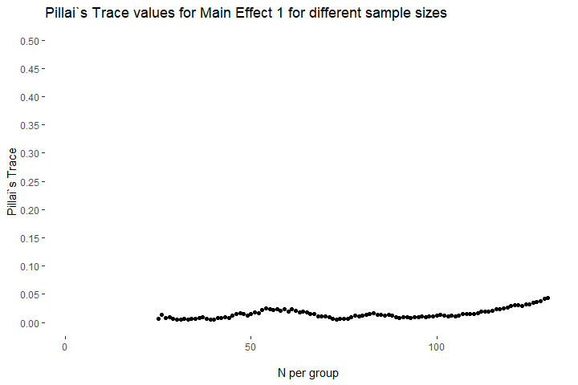

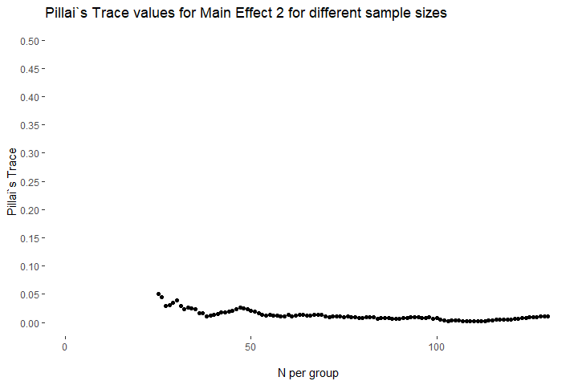

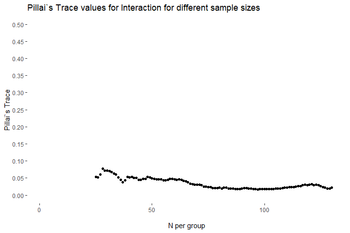

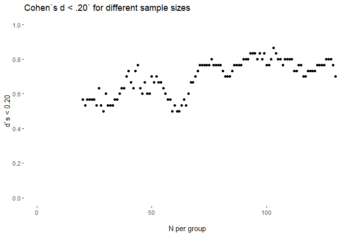

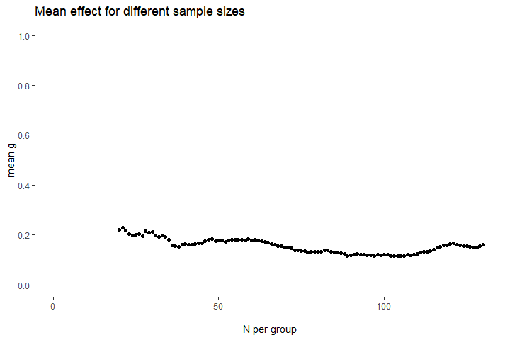

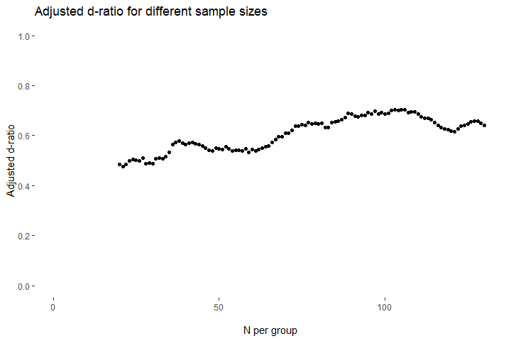

```r
# Plotting trend over increasing sample size
Plot_MAGMA(Balance = Balance_2x2_exact,
           criterion = c("Pillai", "d_ratio", "mean_g", "Adj_d_ratio")) #Could be omitted
```

```r
# Creating table
Table_MAGMA(Balance = Balance_2x2_exact,
            filename = "Balance_2x2_exact.docx")
```

```
#> Balance table successfully created!
#> # A tibble: 6 × 8
#>   Criterion_optimized Pillai_Trace_ME1 Pillai_Trace_ME2 Pillai_Trace_IA d_ratio
#>   <chr>                          <dbl>            <dbl>           <dbl>   <dbl>
#> 1 Best Pillai ME 1                0                0.04            0.07   0.6
#> 2 Best Pillai IA                  0.01             0.01            0.02   0.833
#> 3 Best mean g                     0.01             0.01            0.02   0.833
#> 4 Best d-ratio                    0.01             0               0.02   0.867
#> 5 Best adj. d-ratio               0.01             0               0.02   0.8
#> 6 Best Pillai ME 2                0.01             0               0.02   0.8
#> # ℹ 3 more variables: mean_g <dbl>, adjusted_d_ratio <dbl>, n_per_group <int>
```

```r
# Computing descriptive statistics and all pairwise effects post matching
descs_2x2_post <- MAGMA_desc(Data = MAGMA_sim_data_2x2_exact,
                             group = c("gifted_support", "enrichment"),
                             covariates = covariates_2x2,
                             step_num = 100,
                             step_var = "step",
                             filename = "stats_2x2_post.docx")
```

```
#> 2x2 groups are represented as 4 groups.
```

```r
descs_2x2_post %>%
  purrr::set_names(c("Overall N", "Overall Mean", "Overall SD",
                     "Sup & No En N", "Sup & No En Mean",
                     "Sup & No En SD",
                     "Sup & En N", "Sup & En Mean", "Sup & En SD",
                     "No Sup & No En N", "No Sup & No En Mean", "No Sup & No En SD",
                     "No Sup & En N", "No Sup & En Mean", "No Sup & En SD",
                     "d YesNo-YesYes", "d YesNo-NoNo", "d YesNo-NoYes",
                     "d YesYes-NoNo", "d YesYes-YNoYes",
                     "d NoNo-NoYes"))
```

```
#>                  Overall N Overall Mean Overall SD Sup & No En N
#> group_long             400         2.50       1.12           100
#> GPA_school             400         3.54       0.86           100
#> IQ_score               400       104.14      11.18           100
#> Motivation             400         3.90       0.85           100
#> parents_academic       400         0.46       0.50           100
#> gender                 400         0.50       0.50           100
#>                  Sup & No En Mean Sup & No En SD Sup & En N Sup & En Mean
#> group_long                   1.00           0.00        100          2.00
#> GPA_school                   3.50           0.92        100          3.60
#> IQ_score                   104.05          11.57        100        105.81
#> Motivation                   3.77           0.86        100          3.92
#> parents_academic             0.47           0.50        100          0.49
#> gender                       0.51           0.50        100          0.46
#>                  Sup & En SD No Sup & No En N No Sup & No En Mean
#> group_long              0.00              100                3.00
#> GPA_school              0.86              100                3.59
#> IQ_score               10.35              100              104.74
#> Motivation              0.85              100                3.96
#> parents_academic        0.50              100                0.51
#> gender                  0.50              100                0.52
#>                  No Sup & No En SD No Sup & En N No Sup & En Mean
#> group_long                    0.00           100             4.00
#> GPA_school                    0.89           100             3.49
#> IQ_score                     10.56           100           101.97
#> Motivation                    0.84           100             3.95
#> parents_academic              0.50           100             0.36
#> gender                        0.50           100             0.52
#>                  No Sup & En SD d YesNo-YesYes d YesNo-NoNo d YesNo-NoYes
#> group_long                 0.00           -Inf         -Inf          -Inf
#> GPA_school                 0.76          -0.11        -0.10          0.01
#> IQ_score                  11.99          -0.16        -0.06          0.18
#> Motivation                 0.85          -0.18        -0.22         -0.21
#> parents_academic           0.48          -0.04        -0.08          0.23
#> gender                     0.50           0.10        -0.02         -0.02
#>                  d YesYes-NoNo d YesYes-YNoYes d NoNo-NoYes
#> group_long                -Inf            -Inf         -Inf
#> GPA_school                0.01            0.14         0.12
#> IQ_score                  0.10            0.34         0.25
#> Motivation               -0.05           -0.04         0.01
#> parents_academic         -0.04            0.27         0.31
#> gender                   -0.12           -0.12         0.00
```

```r
MAGMA_sim_data_2x2_exact <- MAGMA_exact(Data = MAGMA_sim_data,
                                        group = c("gifted_support", "enrichment"),
                                        dist = "ps_2x2",
                                        exact = "teacher_ability_rating",
                                        cores = 2)
```

```r
str(MAGMA_sim_data_2x2_exact)
```

```
#> 'data.frame':    520 obs. of  18 variables:
#>  $ ID                    : int  1 2 3 4 5 6 10 13 14 16 ...
#>  $ gender                : int  1 0 1 1 1 0 0 1 0 1 ...
#>  $ gifted_support        : int  1 1 1 1 1 1 1 0 0 0 ...
#>  $ teacher_ability_rating: int  3 2 2 1 3 3 1 3 2 1 ...
#>  $ enrichment            : int  0 1 0 1 0 0 1 0 0 1 ...
#>  $ parents_academic      : int  1 1 1 0 1 0 0 0 0 0 ...
#>  $ GPA_school            : num  4.73 4.41 3.23 2.88 2.98 ...
#>  $ IQ_score              : num  111.6 97.8 120.1 97.9 74.4 ...
#>  $ Motivation            : num  5.36 4.41 3.57 4.34 3.54 ...
#>  $ college_GPA           : num  4.01 3.41 2.73 4.02 4.09 ...
#>  $ support_enrichment    : int  3 4 3 4 3 3 4 1 1 2 ...
#>  $ ps_tar                : num  0.0657 0.1085 0.1899 0.4261 0.4782 ...
#>  $ ps_2x2                : num  0.3 0.32 0.21 0.237 0.571 ...
#>  $ ps_gifted             : num  0.431 0.364 0.626 0.353 0.187 ...
#>  $ group_long            : num  1 2 1 2 1 1 2 3 3 4 ...
#>  $ step                  : num  58 7 116 88 48 19 62 101 82 114 ...
#>  $ weight                : num  1 1 1 1 1 1 1 1 1 1 ...
#>  $ distance              : num  1.50e-03 1.76e-05 5.02e-01 9.73e-02 6.57e-04 ...
```

```r
# Estimating Balance
Balance_2x2_exact <- Balance_MAGMA(Data = MAGMA_sim_data_2x2_exact,
                                   group = c("gifted_support", "enrichment"),
                                   covariates = covariates_2x2,
                                   step = "step") #Not necessary to define here
```

```r
# Balance criteria for 100 cases per group
Balance_100_2x2_criteria_exact <- Balance_extract(Balance = Balance_2x2_exact,
                                                  samplesize = 100,
                                                  effects = FALSE)
Balance_100_2x2_criteria_exact
```

```
#> Pillai's Trace ME 1 Pillai's Trace ME 2   Pillai's Trace IA             d-ratio
#>                0.01                0.01                0.02                0.77
#>              mean g        adj. d-ratio
#>                0.12                0.69
```

```r
# Extracting pairwise effects for 100 cases per group
Balance_100_2x2_effects_exact <- Balance_extract(Balance = Balance_2x2_exact,
                                                 samplesize = 100,
                                                 effects = TRUE)
Balance_100_2x2_effects_exact
```

```
#>       GPA_school_1_2         IQ_score_1_2       Motivation_1_2
#>                 0.12                 0.16                 0.17
#> parents_academic_1_2           gender_1_2       GPA_school_1_3
#>                 0.04                 0.10                 0.10
#>         IQ_score_1_3       Motivation_1_3 parents_academic_1_3
#>                 0.06                 0.23                 0.08
#>           gender_1_3       GPA_school_1_4         IQ_score_1_4
#>                 0.02                 0.01                 0.18
#>       Motivation_1_4 parents_academic_1_4           gender_1_4
#>                 0.21                 0.22                 0.02
#>       GPA_school_2_3         IQ_score_2_3       Motivation_2_3
#>                 0.02                 0.10                 0.05
#> parents_academic_2_3           gender_2_3       GPA_school_2_4
#>                 0.04                 0.12                 0.14
#>         IQ_score_2_4       Motivation_2_4 parents_academic_2_4
#>                 0.34                 0.04                 0.26
#>           gender_2_4       GPA_school_3_4         IQ_score_3_4
#>                 0.12                 0.12                 0.24
#>       Motivation_3_4 parents_academic_3_4           gender_3_4
#>                 0.01                 0.30                 0.00
```

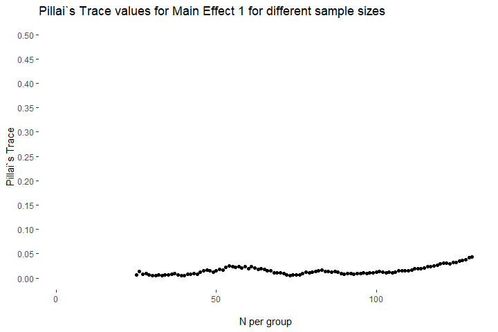

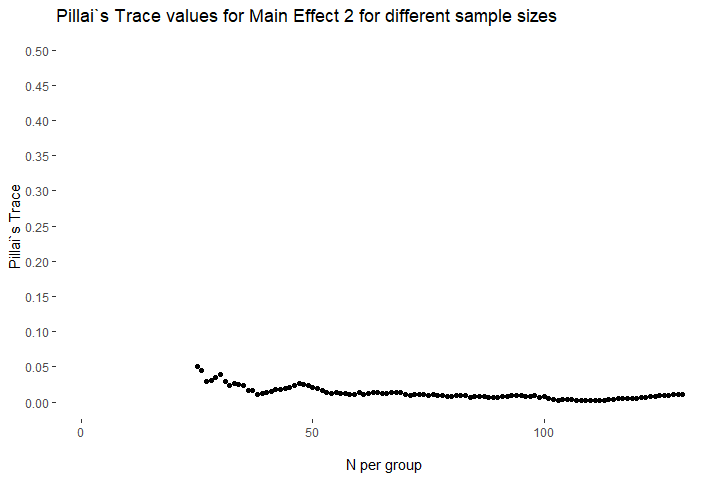

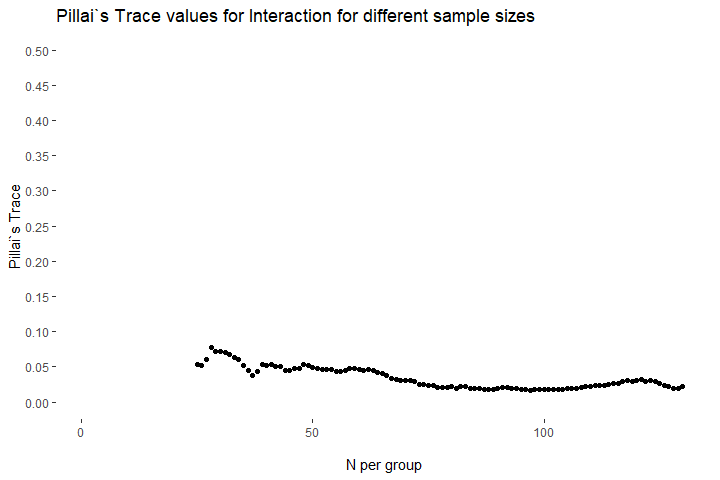

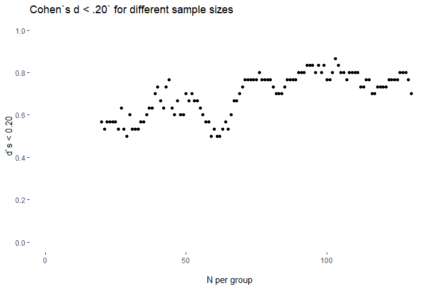

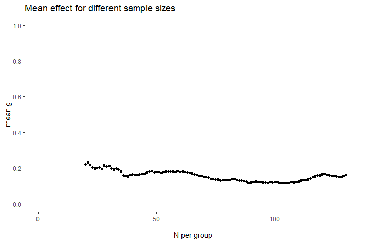

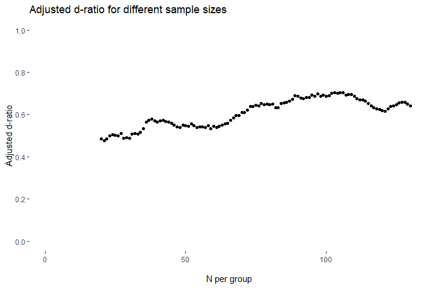

```r
# Plotting trend over increasing sample size
Plot_MAGMA(Balance = Balance_2x2_exact,
           criterion = c("Pillai", "d_ratio", "mean_g", "Adj_d_ratio")) #Could be omitted
```

```r
# Creating table
Table_MAGMA(Balance = Balance_2x2_exact,
            filename = "Balance_2x2_exact.docx")
```

```
#> Balance table successfully created!
#> # A tibble: 6 × 8
#>   Criterion_optimized Pillai_Trace_ME1 Pillai_Trace_ME2 Pillai_Trace_IA d_ratio
#>   <chr>                          <dbl>            <dbl>           <dbl>   <dbl>
#> 1 Best Pillai ME 1                0                0.04            0.07   0.6
#> 2 Best Pillai IA                  0.01             0.01            0.02   0.833
#> 3 Best mean g                     0.01             0.01            0.02   0.833
#> 4 Best d-ratio                    0.01             0               0.02   0.867
#> 5 Best adj. d-ratio               0.01             0               0.02   0.8
#> 6 Best Pillai ME 2                0.01             0               0.02   0.8
#> # ℹ 3 more variables: mean_g <dbl>, adjusted_d_ratio <dbl>, n_per_group <int>
```

```r
# Computing descriptive statistics and all pairwise effects post matching
descs_2x2_post <- MAGMA_desc(Data = MAGMA_sim_data_2x2_exact,
                             group = c("gifted_support", "enrichment"),
                             covariates = covariates_2x2,
                             step_num = 100,
                             step_var = "step",
                             filename = "stats_2x2_post.docx")
```

```
#> 2x2 groups are represented as 4 groups.
```

```r
descs_2x2_post %>%
  purrr::set_names(c("Overall N", "Overall Mean", "Overall SD",
                     "Sup & No En N", "Sup & No En Mean",
                     "Sup & No En SD",
                     "Sup & En N", "Sup & En Mean", "Sup & En SD",
                     "No Sup & No En N", "No Sup & No En Mean", "No Sup & No En SD",
                     "No Sup & En N", "No Sup & En Mean", "No Sup & En SD",
                     "d YesNo-YesYes", "d YesNo-NoNo", "d YesNo-NoYes",
                     "d YesYes-NoNo", "d YesYes-YNoYes",
                     "d NoNo-NoYes"))
```

```
#>                  Overall N Overall Mean Overall SD Sup & No En N
#> group_long             400         2.50       1.12           100
#> GPA_school             400         3.54       0.86           100
#> IQ_score               400       104.14      11.18           100
#> Motivation             400         3.90       0.85           100
#> parents_academic       400         0.46       0.50           100
#> gender                 400         0.50       0.50           100
#>                  Sup & No En Mean Sup & No En SD Sup & En N Sup & En Mean
#> group_long                   1.00           0.00        100          2.00
#> GPA_school                   3.50           0.92        100          3.60
#> IQ_score                   104.05          11.57        100        105.81
#> Motivation                   3.77           0.86        100          3.92
#> parents_academic             0.47           0.50        100          0.49
#> gender                       0.51           0.50        100          0.46
#>                  Sup & En SD No Sup & No En N No Sup & No En Mean
#> group_long              0.00              100                3.00
#> GPA_school              0.86              100                3.59
#> IQ_score               10.35              100              104.74
#> Motivation              0.85              100                3.96
#> parents_academic        0.50              100                0.51
#> gender                  0.50              100                0.52
#>                  No Sup & No En SD No Sup & En N No Sup & En Mean
#> group_long                    0.00           100             4.00
#> GPA_school                    0.89           100             3.49
#> IQ_score                     10.56           100           101.97
#> Motivation                    0.84           100             3.95
#> parents_academic              0.50           100             0.36
#> gender                        0.50           100             0.52
#>                  No Sup & En SD d YesNo-YesYes d YesNo-NoNo d YesNo-NoYes
#> group_long                 0.00           -Inf         -Inf          -Inf
#> GPA_school                 0.76          -0.11        -0.10          0.01
#> IQ_score                  11.99          -0.16        -0.06          0.18
#> Motivation                 0.85          -0.18        -0.22         -0.21
#> parents_academic           0.48          -0.04        -0.08          0.23
#> gender                     0.50           0.10        -0.02         -0.02
#>                  d YesYes-NoNo d YesYes-YNoYes d NoNo-NoYes
#> group_long                -Inf            -Inf         -Inf
#> GPA_school                0.01            0.14         0.12
#> IQ_score                  0.10            0.34         0.25
#> Motivation               -0.05           -0.04         0.01
#> parents_academic         -0.04            0.27         0.31
#> gender                   -0.12           -0.12         0.00
```

# References

Austin, P. C. (2014). A comparison of 12 algorithms for matching on the propensity score. Statistics in Medicine, 33(6), 1057–1069. https://doi.org/10.1002/sim.6004

Feuchter, M. D., Urban, J., Scherrer, V., Breit, M. L., & Preckel, F. (2022). Introduction and Demonstration of the Many-Group Matching (MAGMA)-Algorithm: Matching Solutions for Two or More Groups. https://doi.org/10.17605/OSF.IO/AEDXB

Fisher, Z., Tipton, E., & Zhipeng, H. (2023). *robumeta: Robust Variance Meta-Regression*. R package version 2.1, https://CRAN.R-project.org/package=robumeta.

Imai, K., & van Dyk, D. A. (2004). Causal Inference With General Treatment Regimes. Journal of the American Statistical Association, 99(467), 854–866. https://doi.org/10.1198/016214504000001187

Jacovidis, J. N. (2017). Evaluating the performance of propensity score matching methods: A simulation study [Doctoral Dissertation]. James Madison University.

Li, M. (2013). Using the Propensity Score Method to Estimate Causal Effects. Organizational Research Methods, 16(2), 188–226. https://doi.org/10.1177/1094428112447816

McCaffrey, D. F., Griffin, B. A., Almirall, D., Slaughter, M. E., Ramchand, R., & Burgette, L. F. (2013). A tutorial on propensity score estimation for multiple treatments using generalized boosted models. Statistics in Medicine, 32(19), 3388–3414. https://doi.org/10.1002/sim.5753

Pastore, M., Loro, P.A.D., Mingione, M., Calcagni, A. (2022). *overlapping: Estimation of Overlapping in Empirical Distributions*. R package version 2.1. https://CRAN.R-project.org/package=overlapping

Powell, M. G., Hull, D. M., & Beaujean, A. A. (2020). Propensity Score Matching for Education Data: Worked Examples. The Journal of Experimental Education, 88(1), 145–164. https://doi.org/10.1080/00220973.2018.1541850

Ridgeway, G., McCaffrey, D. F., Morral, A. R., Cefalu, M., Burgette, L. F., Pane, J. D., & Griffin, B. A. (2015). Toolkit for Weighting and Analysis of Nonequivalent Groups: A tutorial for the twang package. Rand.

Rosenbaum, P. R., & Rubin, D. B. (1983). The central role of the propensity score in observational studies for causal effects. Biometrika, 70(1), 41–55. https://doi.org/10.1093/biomet/70.1.41

Rosenbaum, P. R., & Rubin, D. B. (1985). Constructing a Control Group Using Multivariate Matched Sampling Methods That Incorporate the Propensity Score. The American Statistician, 39(1), 33–38.

Stuart, E. A. (2010). Matching methods for causal inference: A review and a look forward. Statistical Science : A Review Journal of the Institute of Mathematical Statistics, 25(1), 1–21. https://doi.org/10.1214/09-STS313

Thoemmes, F. J., & Kim, E. S. (2011). A Systematic Review of Propensity Score Methods in the Social Sciences. Multivariate Behavioral Research, 46(1), 90–118. https://doi.org/10.1080/00273171.2011.540475

Viechtbauer, W. (2010). Conducting meta-analyses in R with the metafor package. Journal of Statistical Software, 36(3), 1-48. https://doi.org/10.18637/jss.v036.i03